# assignment04

Elena Bagnera

10/3/2021

*Notice: you can access my GitHub folder here: https://github.com/elenabagnera/assignment04*

## 1) Spending & tax revenue decentralization

Federal countries tend to be the most fiscally decentralized countries. The graph shows that in these, expenditure is more decentralized to subnational governments than tax revenue is. For example, in Canada, about 67% of the total public expenditure comes from subnational governments (including local and states), while only about 55% of the total tax revenue is raised subnationally. This is not a surprising trend as the difference between the two types of decentralization represents subnational level intergovernmental transfers and subnational borrowing, both of which are common practice in federal states.

```r
countries <- c("United States", "Canada", "Switzerland", "Australia", "Germany", "Brazil") #selecting countries for my analysis

imf_fd_graph1 <- imf_fd %>%
  filter(year==2018) %>%
  select(country, sd_sng, rd_sng) %>%
  filter(country %in% countries) %>%
  pivot_longer(
cols = c(sd_sng, rd_sng),
names_to = "FD_type",
values_to = "value"
  )
```

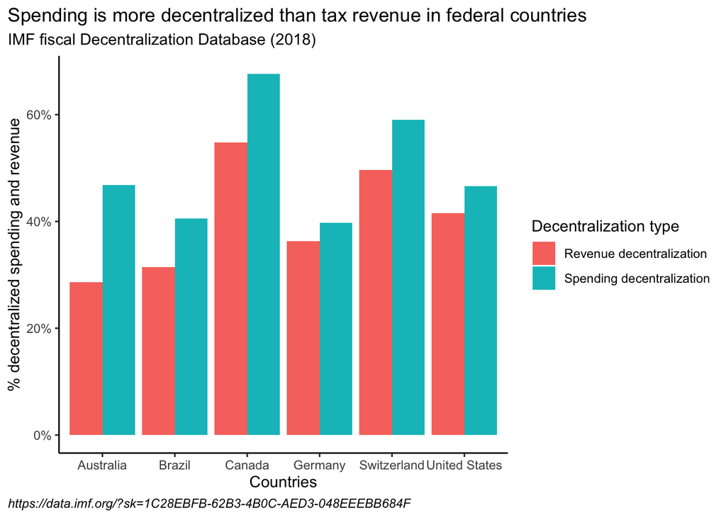

```r
imf_fd_graph1 %>%
  ggplot() +
  geom_col(mapping = aes(x = country, y = value, fill=FD_type), position="dodge")+
  theme_classic() +
  xlab("Countries") +
  ylab("% decentralized spending and revenue") +
  labs(caption="https://data.imf.org/?sk=1C28EBFB-62B3-4B0C-AED3-048EEEBB684F") +
  labs(title = "Spending is more decentralized than tax revenue in federal countries", subtitle="IMF fiscal Decentralization Database (2018)") +
 scale_fill_discrete(name = "Decentralization type", labels = c("Revenue decentralization", "Spending decentralization")) +
  theme(plot.caption = element_text(hjust = 0, face= "italic"),
        plot.title.position = "plot",
        plot.caption.position =  "plot") +
   scale_y_continuous(labels = scales::percent)
```

## 2) Spain’s decentralization trends

This suggests that Spain could be an interesting case study country given the amount of variation from year to year. This chart also draws attention to possible exogenous shocks to decentralization reforms. For instance, from 2010 to 2012, both decentralized tax and total revenue saw a fast increase by about 5 percentage points, while spending dropped at the same time. This could reflect the consequences of austerity measures adopted after the 2008 financial crisis and could be a further topic of exploration.

```r
imf_fd_graph2 <- imf_fd %>%
  filter(country=="Spain") %>%
  filter(year>=1980) %>%
  select(country, year, sd_sng, rd_sng, taxd_sng) %>%
  rename("Spending"=sd_sng, "Tax revenue"=taxd_sng, "Total revenue"=rd_sng) %>%
  pivot_longer(
cols = c("Spending", "Total revenue", "Tax revenue"),
names_to = "FD_type",
values_to = "value"
  )
```

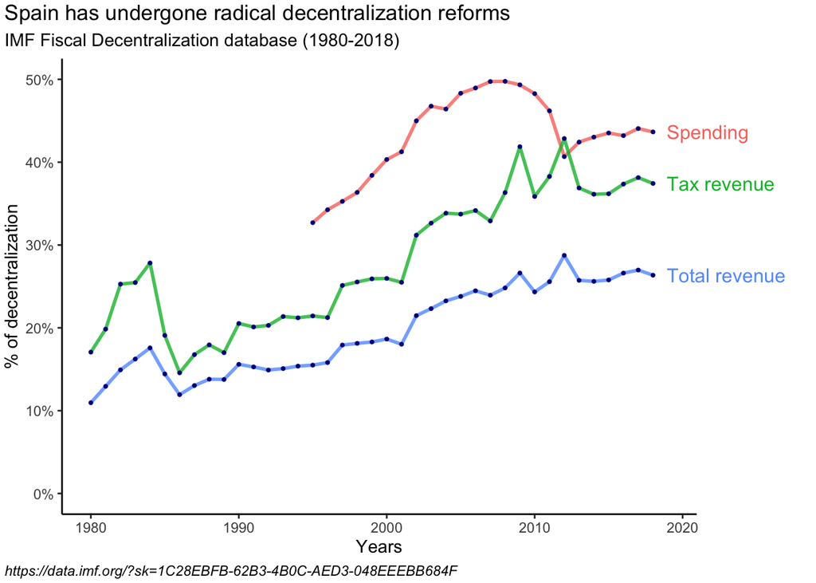

```r
labels <- c("Decentralized tax revenue", "Decentralized revenue", "Decentralized spending")
library(directlabels)

imf_fd_graph2 %>%
ggplot() +
geom_line(mapping = aes(x = year, y = value, color=FD_type), size=1, alpha= 0.8) +
  geom_point(mapping = aes(x = year, y = value), size=0.7, color="dark blue") +
  geom_dl(aes(x=year, y=value, label=FD_type, color=FD_type), method = list(dl.trans(x = x + .3), "last.bumpup")) +
  theme_classic() +
  xlab("Years") +
  ylab("% of decentralization") +
  labs(caption="https://data.imf.org/?sk=1C28EBFB-62B3-4B0C-AED3-048EEEBB684F") +
  labs(title = "Spain has undergone radical decentralization reforms", subtitle="IMF Fiscal Decentralization database (1980-2018)", fill="") +
  theme(plot.caption = element_text(hjust = 0, face= "italic"),
        plot.title.position = "plot",
        plot.caption.position =  "plot")  +
  scale_y_continuous(labels = scales::percent_format(accuracy=1), limits=c(0, 0.5)) +
  coord_cartesian(clip = 'off') +
  theme(legend.position = 'none',
  plot.margin = margin(0.1, 2.6, 0.1, 0.1, "cm"))
```

## 3) Renewabe energy & country population

This graph shows a weak negative correlation between the population of a country and its percentage of renewables in the energy mix. The energy systems of the most populous countries in the world, tend to have a low renewable energy share, suggesting that they are lagging behind in the energy transition. One exception seems to be Brazil, which despite being among the top 8 most populous countries, in 2019, 45% of its energy mix was made up of renewables.

```r
regions <- c("North America", "Europe", "Asia Pacific", "Africa", "South & Central America", "Other South America", "Other North America", "Other Asia & Pacific", "Europe (other)", "Other Southern Africa", "Other Northern Africa", "Other South America", "Other Southern Africa", "World") #listing regions to be able to remove them from the data

owid_energy_graph1 <- owid_energy %>%
  filter(
    year==2019,
    !is.na(renewables_share_energy),
    !country %in% regions) %>%
  select(country, year, population, renewables_share_energy)


highlights <- owid_energy_graph1 %>%
  filter(country=="China"| country=="India"| country=="United States" | country=="Russia"| country=="Brazil"| country=="Pakistan"| country=="Bangladesh" | country=="Indonesia")
```

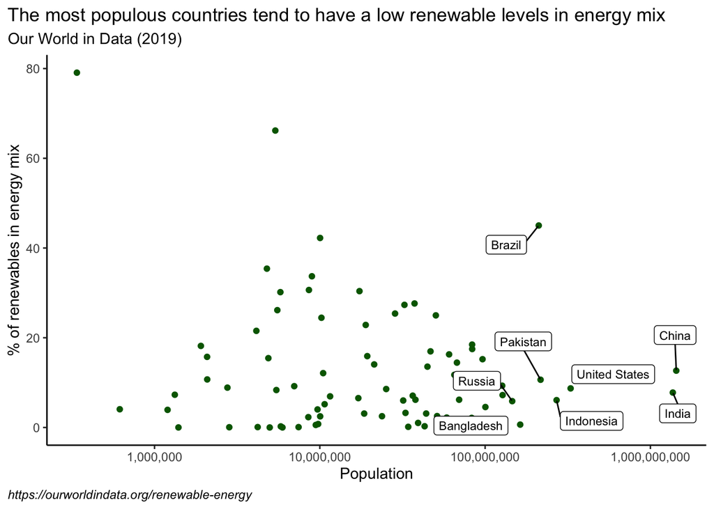

```r
owid_energy_graph1 %>%
    ggplot() +
  geom_point(mapping = aes(x = population, y = renewables_share_energy), size=1.5, color="dark green") +
  geom_label_repel(data=highlights, aes(x=population, y=renewables_share_energy, label=country), size=3, box.padding = 0.5, max.overlaps=Inf) +
  theme_classic() +
  xlab("Population") +
  ylab("% of renewables in energy mix") +
  labs(caption="https://ourworldindata.org/renewable-energy") +
  labs(title = "The most populous countries tend to have a low renewable levels in energy mix", subtitle="Our World in Data (2019)", fill="") +
  theme(plot.caption = element_text(hjust = 0, face= "italic"),
        plot.title.position = "plot",
        plot.caption.position =  "plot")+
  scale_x_log10(labels=scales::comma)
```

## 4)Renewable energy types

```r
main_econ <-c("Japan", "United States", "China", "India", "Germany", "United Kingdom")

owid_energy_graph2 <- owid_energy %>%
  filter(year==2019, country %in% main_econ) %>%
  select(country, wind_share_energy, solar_share_energy, hydro_share_energy, biofuel_share_energy, other_renewables_share_energy) %>%
  pivot_longer(
cols = c(wind_share_energy, solar_share_energy, hydro_share_energy, biofuel_share_energy, other_renewables_share_energy),
names_to = "renewable_type",
values_to = "value"
  )
```

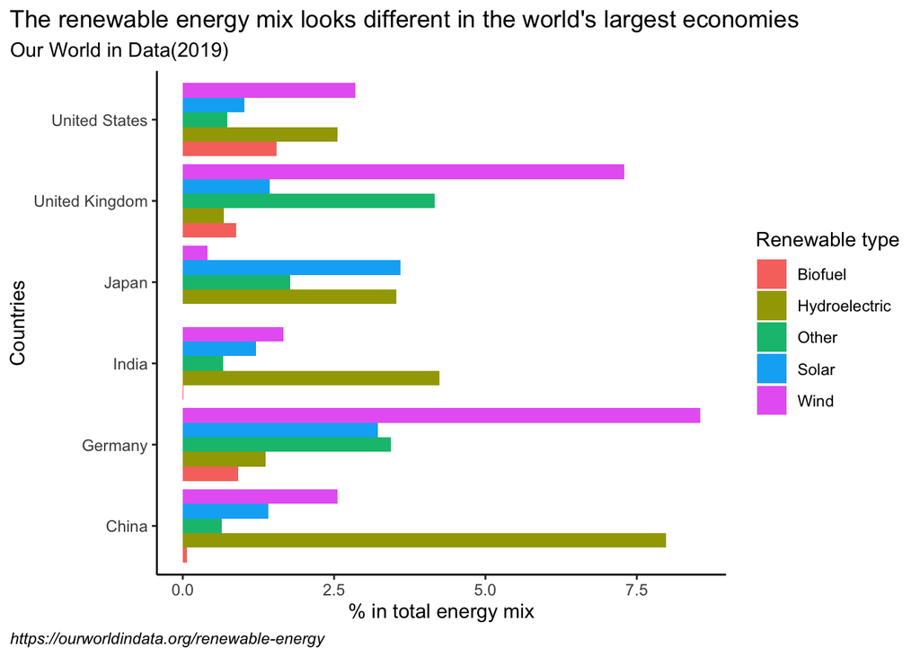

```r
    owid_energy_graph2 %>%
      ggplot() +
      geom_col(mapping = aes(x = country, y = value, fill=renewable_type), position="dodge") +
        theme_classic() +
        xlab("Countries") +
        ylab("% in total energy mix") +
        labs(caption="https://ourworldindata.org/renewable-energy") +
        labs(title = "The renewable energy mix looks different in the world's largest economies", subtitle="Our World in Data(2019)") +
      coord_flip() +
  theme(plot.caption = element_text(hjust = 0, face= "italic"),
        plot.title.position = "plot",
        plot.caption.position =  "plot") +
      scale_fill_discrete(name = "Renewable type", labels = c("Biofuel", "Hydroelectric", "Other", "Solar", "Wind"))
```